# Introducción a la probabilidad y la estadística

Carlos J. Gil Bellosta

2016-02-11

# Introducción a la probabilidad

# Los eventos: conjuntos de hechos que pueden ocurrir o no

- Un *evento* puede ocurrir o no (luego se le asignaran probabilidades de ocurrencia).
- Los eventos son conjuntos:
  - $A \cup B$: evento A o evento B
  - $A \cap B$: evento A y evento B
  - $\Omega; \emptyset$: cualquier evento; ningún evento
  - $\Omega \setminus A$: que no ocurra A (complementario)
- Con los eventos se *opera* como con conjuntos.

# Variables aleatorias

- Una variable aleatoria es una función que *genera eventos*
- Los eventos que genera son del tipo $X < 7$ o $X = 7$
- Por ejemplo, “que gane/pierda/empate el Real Madrid” puede escribirse de la forma $X = 1$ / $X = -1$ / $X = 0$
- Que el Real Madrid no gane es el evento $X \in \{0, -1\}$
- Casi siempre vamos a fijarnos en eventos *generados* por variables aleatorias

# Probabilidad: una función sobre conjuntos

- La probabilidad es una función que asigna a conjuntos (eventos) un número entre 0 y 1: $P(A) = x, 0 \le x \le 1$.
- Intuición de la probabilidad de un evento (Savage):

> La máxima cantidad de dinero que apostarías si alguien te ofreciese un euro si el evento en cuestión sucede.

¡Piensa en euros!

# Axiomas de probabilidad (Kolmogorov)

- $P(A) \ge 0$.
- $P(\Omega) = 1$ ($\Omega$ es *cualquier cosa*).
- $P(\cup A_i) = \sum_i P(A_i)$ si los $A_i$ son eventos *mutuamente excluyentes*.

Si los agentes son racionales, la probabilidad subjetiva (basada en apuestas) cumple estos axiomas.

# El caso de Linda

Linda is thirty-one years old, single, outspoken, and very bright. She majored in philosophy. As a student, she was deeply concerned with issues of discrimination and social justice, and also participated in anti-nuclear demonstrations…The respondents are asked to rank in order of likelihood various scenarios: Linda is

1. an elementary school teacher,
2. active in the feminist movement,
3. a bank teller,
4. an insurance salesperson, or
5. a bank teller also active in the feminist movement.

# Azar, riesgo, incertidumbre

- Azar: los eventos están acotados y el cálculo de la probabilidad es pura aritmética. P.e., lanzamientos de moneda, ruletas, dados, etc.
- Incertidumbre y riesgo: universo no acotado de eventos, con cisnes negros, etc.

> ¡Son muy distintos cualitativamente!

# ¿Qué significa acertar?

En ciencia de datos está de moda predecir y acertar; sin embargo, si alguien dice

- la probabilidad de que llueva mañana es del 30%
- la probabilidad de que Rajoy sea el próximo presidente es del 25%
- la probabilidad de sacar dos caras en dos tiradas de dados es del 25%
- la probabilidad de que una determinada transacción sea fraudulenta es del 10%

¿cómo sabemos si *acierta* o no *acierta*?

# Independencia de eventos

- Cualitativamente, dos eventos son independientes si sabe si uno ocurre no aporta información sobre si el otro ocurre también.
- Cuantitativamente, $P(A \cap B) = P(A)P(B)$.
- Ejercicios:
  - Piensa en dos eventos independientes; piensa en dos eventos no independientes.
  - ¿cuál es la probabilidad de sacar dos caras consecutivas tirando una moneda?

# Probabilidad condicional: cambio de universo

- Cuando decimos $P(A)$ queremos decir $P(A | \Omega)$ (i.e., probabilidad dentro de un determinado universo).
- ¡A veces el universo cambia! Típicamente, porque tenemos información adicional.
- Ejemplo: ¿cuál es la probabilidad de que el Madrid gane el próximo partido? ¿Pero y si sabemos que Ronaldo está lesionado?
- En el caso anterior tenemos $\Omega^\prime \subset \Omega$ y dos probabilidades, $P(A|\Omega)$ y $P(A | \Omega^\prime)$.

# Probabilidad condicional: más ejemplos

- Tasa de paro femenina
- Ganar más de 2000 euros al mes si no has acabado el bachillerato
- Que suba el Ibex si se ha caído la bolsa china

# Probabilidad condicional: cálculo de probabilidades

- Para calcular $P(A|B)$ necesitamos $P(B)$ y $P(A \cap B)$; entonces, $P(A|B) = P(A \cap B) / P(B)$.
- En la práctica, sin embargo, siempre te dan $P(A|B)$: tasa de paro femenina, etc.

# Probabilidad condicional: probabilidad total

- Sirve para calcular la probabilidad de un evento a partir de una serie de probabilidades condicionales
- Probabilidad total:
  $$P(A) = P(A | B) P(B) + P(A | B^\prime) P(B^\prime)$$
  donde $B^\prime$ es el complementario de $B$
- Ejemplo: calcular la tasa de paro nacional si se conoce la masculina, la femenina y la proporción de hombres en la población activa.
- ¡Es una media ponderada (por las probabilidades de $B$ y $B^\prime$)!

# Distribuciones de probabilidad discretas

# Axiomas de probabilidad y distribuciones

- Los axiomas de probabilidad son la gramática; las distribuciones son el léxico
- Si $A \subset B$, los axiomas de probabilidad te dicen que $P(A) \le P(B)$
- Pero, ¿cuánto es $P(A)$ y $P(B)$?
- ¿Cómo podemos asignar probabilidades a eventos?

# Probabilidades sobre conjuntos finitos

- Monedas: $P(H) = P(T) = 0.5$
- Dados: $P(i) = 1/6, i= 1, \dots, 6$
- Las probabilides pueden ser diferentes
- Ejercicio: ¿Cuál es la probabilidad de sacar un 2 o un 6 tirando un dado? (Usa los axiomas de probabilidad)
- Ejercicio: ¿Cuál es la probabilidad de no sacar un 1 tirando un dado?
- Ejercicio: ¿Cuál es la probabilidad de no sacar ningún 1 después de tirar n dados? (Usa la independencia)

# Probabilidades sobre conjuntos finitos en R

- Monedas: `rbinom(10, 1, 0.5)` (10 tiradas independientes)
- Dados: `sample(1:6, 10, replace = T)`
- Aproximación de la probabilidad de sacar un 2 o un 6 tirando dados:

```r
mean(sample(1:6, 10000, replace = T) %in% c(2,6))
```

```
## [1] 0.333
```

- Ejercicio: ¿sabrías calcular esa probabilidad a mano?
- Ejercicio: estudia `?sample` para ver cómo muestrear números con probabilidades desiguales.

# Un ejercicio: peces en un lago

En un lago hay 1000 peces. Capturas 100, los marcas y los tiras de nuevo al lago. Luego capturas otros 100 y cuentas cuántos tienen marca.

Calcula una aproximación a la probabilidad de que haya 10 peces marcados en la segunda captura.

Pista: selecciona dos veces 100 elementos de entre 1000 y cuenta las coincidencias.

Una mejora: si lo piensas bien, solo hace falta seleccionar una vez, no dos (y la simulación es más rápida).

# Distribución de Bernoulli

- Es la de una moneda con probabilidad $p$ de cara.
- Solo toma valores en 0 y 1.
- En R se muestrea haciendo `rbinom(1, 1, p)`.
- Ejercicios:
  - ¿Cuál es su media? ¿Su varianza?
  - ¿Cómo se pueden estimar esas magnitudes en R (para un valor dado de $p$)?
  - ¿Cómo es su histograma?
- ¡Es la base de muchos modelos de clasificación!

# Distribución binomial

- Es la distribución de una suma de muestras de la de Bernoulli
- Ej.: ¿cuántas caras obtengo después de tirar una moneda 15 veces?
- En R, `rbinom(1, 15, 0.5)`, que es lo mismo que `sum(rbinom(15, 1, 0.5))`.
- ¿Cuál es su media y su varianza?
- ¿Qué pinta tiene su histograma?

# Distribución de Poisson

- Es para conteos de eventos independientes: número de mujeres asesinadas, de llamadas telefónicas, número de compras que hace un cliente, etc.
- A diferencia de la binomial, no hay límite superior
- Depende de un parámetro que es la media (¡y la varianza!)
- En R, `rpois(1000, 7)`
- Ejercicio: estima la media y la varianza de la distribución de Poisson
- `rpois(1000, 7)` es aproximadamente `rbinom(1000, 1000000, 7/1000000)`
- Ejercicio: representa ambos histogramas y ver que efectivamente, se parecen.

# Distribuciones de probabilidad continuas

# Eventos y distribuciones continuas

- Probabilidad de que mañana la bolsa baje más del 1%
- Probabilidad de que alguien sin estudios gane más de 3000 euros al mes
- Probabilidad de que alguien mida más de 1.90 y pese menos de 80 kilos
- Probabilidad de que una mujer de 80 años tenga una tensión arterial entre a y b
- Probabilidad de que alguien sano tenga una concentración de urea en la sangre superior a x

# Función de densidad

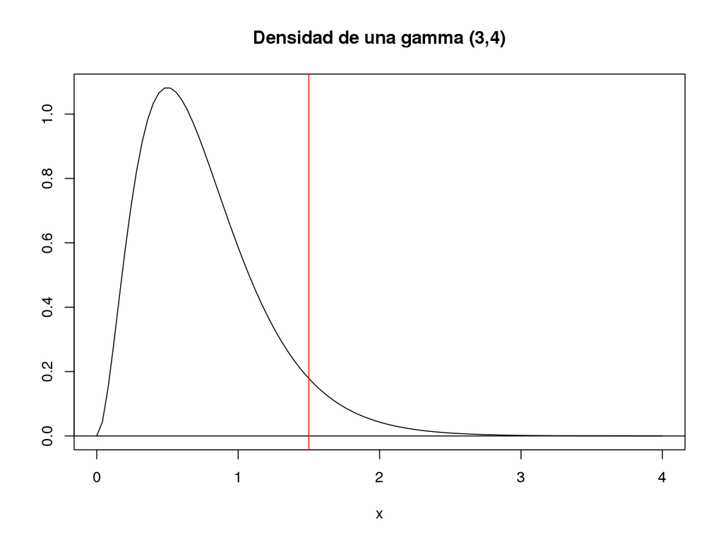

# Propiedades de la densidad

- Siempre es positiva ($\ge 0$)
- Su integral es 1 (su integral es $P(\Omega)$)
- Su integral entre a y b es la probabilidad del evento $a < x < b$
- En R, la densidad es la función `d.*` (`dnorm`, `dgamma`, etc.)

# La función de probabilidad

- Hay eventos muy imporantes: $X < a$
- La función de probabilidad es precisamente $F(a) = P(X < a)$
- Nota: la probabilidad de $X < a$ o $X > b$ es $F(a) + 1 - F(b)$. Este evento es muy importante: es la probabilidad de obtener resultados *raros*: o muy altos o muy bajos.
- En R, la función de probabilidad es la `p.*` (`pnorm`, `pgamma`, etc.)
- La función de probabilidad crece de 0 a 1

# La función de cuantiles

- Es la inversa de la de probabilidad
- ¿Cuál es el número $a$ por debajo del cual la probabilidad es inferior a, p.e., 5%?
- En R, la función de cuantiles es la `q.*` (`qnorm`, `qgamma`, etc.)
- E.j.: el cuantil correspondiente a 0.5 es la mediana

# Nota: funciones d, p y q para distribuciones discretas

- Las distribuciones discretas también tienen asociadas estas funciones
- Aunque, generalmente, se usen menos (¡generalmente!)
- Digamos que tienen más sentido para distribuciones continuas
- Ejemplo: supongamos que el número de mujeres asesinadas en España sigue una Poisson de parámetro 60. ¿Cuál es la probabilidad de que un año mueran asesinadas más de 75 mujeres?

# Distribuciones “con nombre”

- Cada evento tiene su propia distribución de densidad (de la que se deducen la de probabilidad, etc.)
- P.e., el número de $l/m^2$ que lloverá mañana (que es una *mezcla* una distribución discreta y una continua y, casi seguro, tiene un pico grande en 0).
- No obstante, algunas distribuciones tienen nombre
- Son útiles porque algunos (¡no tantos!) procesos se comportan como ellas.
- También porque sus características pueden ser extrapolables a otras parecidas a ellas (aunque no lo sean exactamente).

# Distribución normal

# Distribución t

- Se parece mucho a la normal (simétrica, acampanada)
- Pero tiene colas más largas (¡outliers!)
- Depende de un parámetro `df`
- Cuanto más grande es `df`, más se parece a la normal (más finas son las colas)
- Cuando `df = 1` se la conoce también como distribución de Cauchy
- ¡La distribución de Cauchy no tiene media!
- Ejercicio: simula un movimiento browniano con incrementos normales y luego sustituye la normal por una distribución t.

# Distribución lognormal

- Es la exponencial de una distribución normal
- El histograma es `hist(exp(rnorm(1000)))` (con los parámetros 0 y 1 por defecto).
- Es asimétrica, con una cola *larga* por la derecha

# Distribución beta

- Toma valores entre 0 y 1
- Es la distribución de una proporción sobre la que se tiene incertidumbre
- Puede ser más o menos simétrica, más o menos *picuda*

# Distribución uniforme

- Su densidad 0 en todas partes menos entre a y b (0 y 1 por defecto)
- En ese rango tiene el valor $1 / (b -a)$
- Todos los valores de ese rango son equiprobables

# ¿Qué distribución tienen mis datos?

- Un problema típico es determinar la distribución de unos datos
- (O la que más se parezca a ellos)
- O ver, p.e., si son o no normales (véase `ks.test`)
- No vamos a hablar de este problema
- Es mejor suponer que los datos tienen la distribución… que tienen

# Mezclas de distribuciones

- Por ejemplo, alturas de personas (que es la mezcla de la de los hombres y las mujeres)
- Permiten generar muchas distribuciones *ad hoc* a partir de distribuciones *base*
- Muestreo de una mezcla de distribuciones:
- Se toma un valor aleatorio (p.e., discreto)
- Se simula de la distribución correspondiente a dicho valor

# Distribuciones modeladas por simulación

- Pérdidas por siniestros en una compañía se seguros:
  - El número de siniestros (por mes) es Poisson
  - El impacto económico es lognormal
  - ¿Cuál es la distribución del impacto económico de los siniestros por mes?
- Ventas digitales
  - El número de visitas diarias es Poisson
  - El número de ventas es una proporción fija (y pequeña)
  - El precio de venta es lognormal

# Introducción a la estadística

# La probabilidad es deductiva…

- Si la probabilidad de $H$ es $p$, *deduce* la probabilidad de $HHT$
- Si $X$ tiene una distribución $N(0,1)$, calcula $P(X > 3)$
- Etc.
- ¡Los parámetros están dados!

# La estadística es inductiva (o abductiva)

- Si he tirado una moneda al aire 100 veces y me han salido 60 caras, ¿me fío de que $p=0.5$?
- En estadística tienes datos y te interesa conocer los parámetros.
- Esos parámetros son los que *gobiernan* el fenómeno aleatorio.
- Razonamiento abductivo: visto un efecto, ¿cuál es la causa más probable?
- Tiene mucho que ver con la teoría de la decisión

# Más sobre peces en el lago

Toma números entre 1000 y 10000 (muchos). Supón que es un número *desconocido* de peces en un lago. Para cada valor, toma 100 peces, márcalos y vuelve a pescar 100 peces.

¿Hay relación entre el número medio de recapturas y el número total de peces en el lago (supuestamente desconocido)?

# Ramas de la estadística

- Descriptiva (estática y poco interesante)
- Estadística pública (censos, muestras, encuestas, etc.)
- Inferencia estadística (a lo que me refiero más arriba: ¡la induccción!), que puede ser frecuentista o bayesiana

Lo que veremos hoy (y casi todo el ML) es frecuentista

# Pruebas de hipótesis

# ¿Normal o excepcional?

Tiramos una moneda 100 veces y tenemos 60 caras… ¿es eso normal si $p=0.5$?

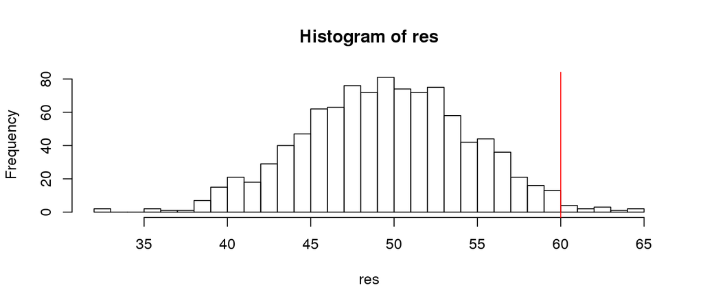

```r
res <- rbinom(1000, 100, 0.5)
hist(res, breaks = 30)
abline(v = 60, col = "red")
```

# El famoso p-valor

Se puede estimar $P(X \ge 60)$ así:

```r
mean(res > 59.5)
```

```
## [1] 0.025
```

¡Ese es el p-valor!

# Más sobre el p-valor

- Es el resultado de comparar un valor observado con una población *normal*.
- Otro ejemplo: te haces un análisis de sangre y tienes $x$ unidades de glucosa por mililitro. ¿Es eso *normal*? Tienes que compararlo con la distribución de la concentración de glucosa de una población *sana*.
- En situaciones como la del ejemplo, tienes que medir (a sujetos); en otras, como la moneda, podemos simular.

# Ya que sabemos de distribuciones…

… el p-valor se puede calcular también así (sin simulaciones):

```r
1 - pbinom(59.5, 100, 0.5)
```

```
## [1] 0.02844397
```

Eso es porque sabemos que la distribución de una tirada de monedas es binomial (¿y si no?).

# Pero la prueba es tan habitual que…

… está empaquetada en R:

```r
binom.test(60, 100, 0.5, "greater")
```

```
##
##  Exact binomial test
##
## data:  60 and 100
## number of successes = 60, number of trials = 100, p-value =
## 0.02844
## alternative hypothesis: true probability of success is greater than 0.5
## 95 percent confidence interval:
##  0.5129758 1.0000000
## sample estimates:
## probability of success
##                    0.6
```

# O bien, usando una aproximación

```r
prop.test(60, 100, p = 0.5, alternative = "greater")
```

```
##
##  1-sample proportions test with continuity correction
##
## data:  60 out of 100, null probability 0.5
## X-squared = 3.61, df = 1, p-value = 0.02872
## alternative hypothesis: true p is greater than 0.5
## 95 percent confidence interval:
##  0.5127842 1.0000000
## sample estimates:
##   p
## 0.6
```

`prop.test` compara proporciones: por ejemplo, dos porteros según el número de paradas vs tiros a puerta.

# Digresión: normal y binomial

La distribución binomial puede aproximarse por una normal:

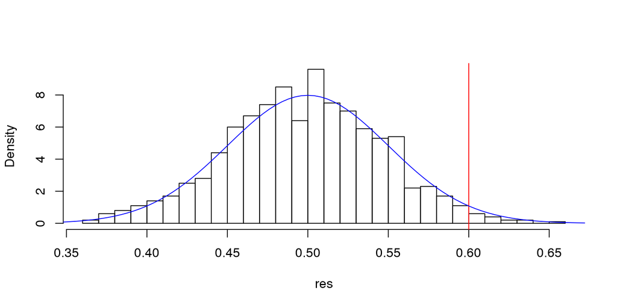

```r
res <- rbinom(1000, 100, 0.5) / 100   # proporciones
hist(res, breaks = 30, freq = FALSE, main = "")
abline(v = 0.6, col = "red")
curve(dnorm(x, 0.5, 0.5 / 10), from = 0.3, to = 0.7, col = "blue", add = T)
```

# Eso justificaba el uso de la normal…

… en la época anterior a los ordenadores:

```r
1 - pnorm(0.6, 0.5, 0.5 / 10)
```

```
## [1] 0.02275013
```

# Teoría de la decisión

- Hemos visto (de muchas maneras) que el p-valor es como del 2%
- ¿Nos creemos que $p = 0.5$?
- Típicamente, se exige que el p-valor exceda el 5% para *no rechazar la hipótesis nula*.
- Error de tipo I: rechazar la hipótesis nula cuando es cierta (digamos que ocurre el 5% de las veces)
- Error de tipo II: aceptar una hipótesis nula cuando es falsa
- Pero la teoría de la decisión es más que eso: impacto económico, etc.

# Características (irreales) de nuestro ejemplo

- Las tiradas son independientes
- Tienen todas la misma distribución (y conocida), Bernuilli
- Podemos hacer más y más tiradas
- ¡Esto es muy atípico!

# Más pruebas de hipótesis clásicas

- Tienes datos (números): ¿proceden de una distribución normal de media/varianza conocida?
- Tienes datos (números): ¿proceden de una distribución normal de media conocida (y varianza desconocida)?
- Tienes dos secuencias de números: ¿tienen la misma media? (Véase la prueba de Student)
- Tienes una secuencia de números: ¿tienen una distribución normal?
- Tienes dos secuencias de números: ¿tienen la misma distribución?
- Tienes dos secuencias de números: ¿tienen la misma varianza?

# Estrategias para implementar pruebas de hipótesis

- Buscar en internet si en R (u otro lugar) está implementada
- Hacer muestreos y calcular los p-valores mediante simulación
- Preguntar a alguien que sepa de eso
- ¡Preguntarte si te crees los resultados o no!

# Ejercicio: paradas de porteros

- Busca “porcentaje paradas porteros liga española” en Google y entra a la página de 20 minutos
- Compara (usando `prop.test`) dos porteros: ¿son *significativamente* distintos?
- Pregúntate: ¿son las *tiradas* “independientes”? ¿Tienen la misma distribución?

# Otras cuestiones

- ¿Podemos comparar la tasa de paro de dos provincias?
- ¿Podemos comparar el sueldo de hombres y mujeres con una prueba de hipótesis de las anteriores?

# Potencia de una prueba

- La potencia es la probabilidad de distinguir un efecto (diferencia) real
- Depende de tres factores:
- El número de muestras (cuanto más muetras, más potencia)
- La diferencia entre las muestras (cuanto más grande, más potencia)
- La varianza (cuando mayor la varianza, menos potencia)